# STAT 211: Normal Distribution

Computing probabilities and quantiles from this important distribution

# The Normal Distribution

## Defining the normal distribution

The normal (also known as ‘Gaussian’) is $X\sim N(\mu,\sigma^2)$:

- $\mu$ is the expected value ($E[X]$)
- $\sigma^2$ is the variance of ($Var[X]$)

Its pdf:

$$f(x)=\frac1{(2\pi\sigma^2)^{1/2}}e^{-\frac{(x-\mu)^2}{2\sigma^2}}$$

(Just like the binomial, you don’t need to know this formula for this class)

## Computing probabilities: old vs. new

Computing probabilities with the normal **requires** computers

In times of yore, this meant using tables:

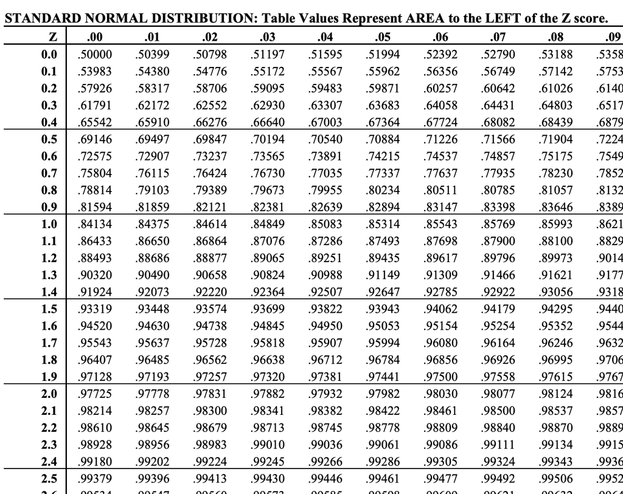

Now, we can just use a computer:

```r
pnorm(1.8,0,1)
```

```
[1] 0.9640697
```

```r
pnorm(1.89,0,1)
```

```
[1] 0.970621
```

# Computing Probabilities and Values

## Computing probabilities

We will always write $X\sim N(\mu,\sigma^2)$ for the normal

R syntax will be specified with $\mu$ and $\sigma = \sqrt{\sigma^2}$ instead

Example

If $X \sim N(5,9)$, then the probability $X$ is less than 4 is:

```r
x       = 4
mu      = 5
sigmaSq = 9
pnorm(x, mu, sqrt(sigmaSq))
```

```
[1] 0.3694413
```

## Computing values (quantiles)

Continuing with $X \sim N(5,9)$:

(that is, normal with expected value 5 and variance 9)

Recall:

For a value $x = 4$, $P(X \leq 4)$:

```r
pnorm(4,5,3)
```

```
[1] 0.3694413
```

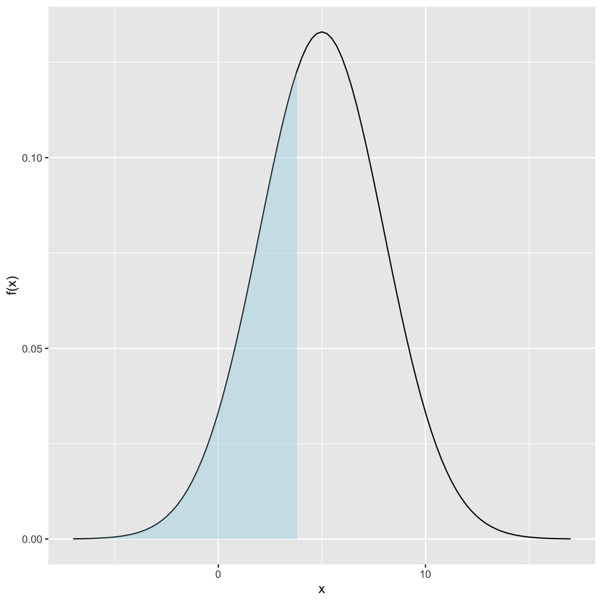

Now, let’s ask the **opposite** question!

For a fixed probability $p$, what is the value $x$ so that $P(X \leq x) = p$?

This value is called a quantile

Example:

What $x$ makes $P(X\leq x) = .7$?

```r
qnorm(.7,5,3)
```

```
[1] 6.573202
```

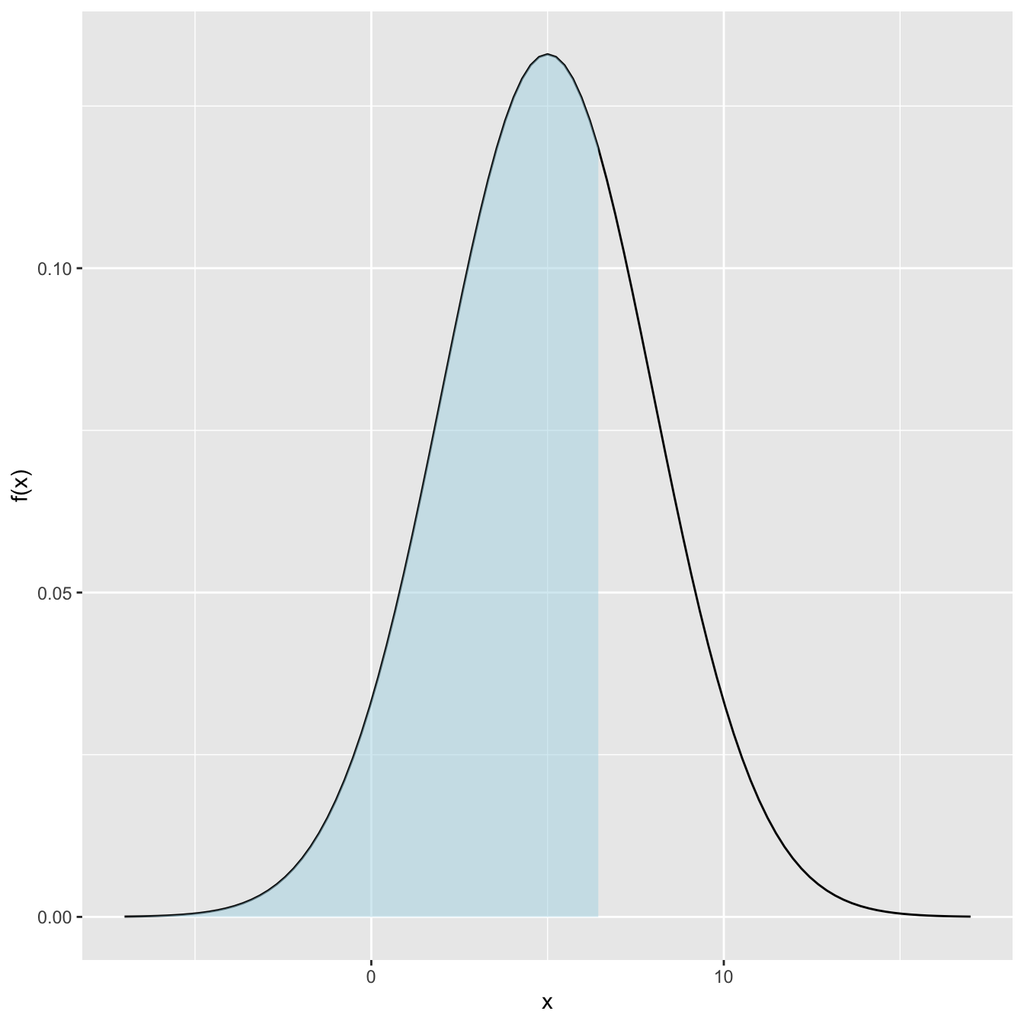

## Using pnorm and qnorm

Concept Check: What would each of the following codes produce?

```r
qnorm( pnorm(3,5,3), 5, 3)
```

. . .

```
[1] 3
```

. . .

```r
pnorm( qnorm(.2,5,3), 5, 3)
```

. . .

```
[1] 0.2
```

## Computing probabilities and values

Suppose $X \sim N(-3.2, 100)$

that is, normal with expected value -3.2 and variance 100

Probability: What is the probability $X$ equals 0?

. . .

This is always zero!

. . .

Probability: What is the probability $X$ is less than 0?

. . .

```r
pnorm(0,-3.2,sqrt(100))
```

```
[1] 0.6255158
```

. . .

Values: at what value $x$ does $P(X\leq x) = .05$?

. . .

```r
qnorm(.05,-3.2,sqrt(100))
```

```
[1] -19.64854
```

## Computing probabilities: SATs

Example

The scores on the SAT math section are $X \sim N(520,3600)$

(that is, normal with expected value 520 and variance 3600)

What is the probability someone scores less than 600?

$P(X \leq 600) = \text{what probability?}$

```r
x       = 600
mu      = 520
sigmaSq = 3600
pnorm(x, mu, sqrt(sigmaSq))
```

```
[1] 0.9087888
```

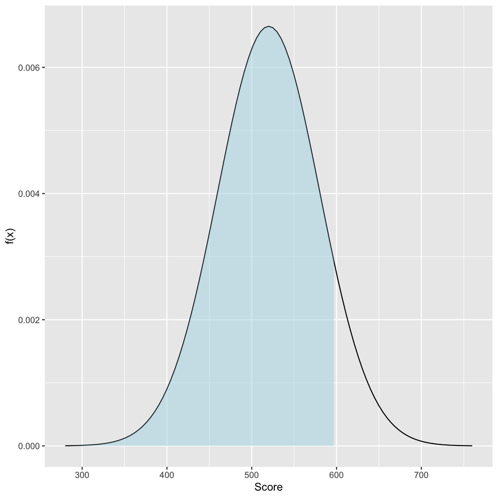

## Computing values: SATs

Example

The scores on the SAT math section are $X \sim N(520,3600)$

The stats dept. admits students scoring above $96^{th}$ percentile

What is the cutoff score ($x$) for recruitment by the stats dept.?

$P(X \leq x) = 0.96$

```r
prob    = .96
mu      = 520
sigmaSq = 3600
qnorm(prob, mu, sqrt(sigmaSq))
```

```
[1] 625.0412
```

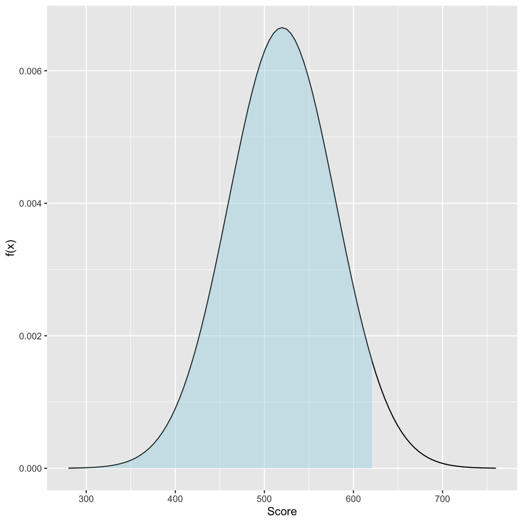

# Transformations

## Transforming Normals: $aX + b$

Suppose again $X \sim N(\mu, \sigma^2)$

If we multiply/add constants $a,b$ to $X$ to form a new rv $Y$:

$$Y = aX + b$$

then $Y \sim(a\mu + b, a^2 \sigma^2)$

(This should remind you of our $E[X]$ and $Var[X]$ results)

Example:

If $X \sim N(150,100)$ then

$$Y = 3X + 30 \sim N(480, 900)$$

## Transforming Normals: inches to cm

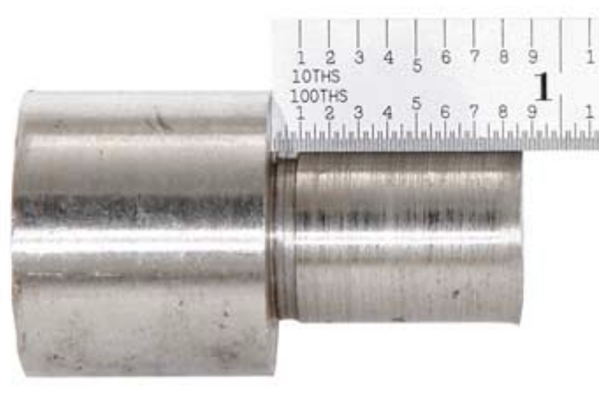

We are measuring a machined part using a ruler on a .01” scale

If several people measure, they will get some random amount of measurement error:

$$X \sim N(.875, .00005)$$

What is the probability that that a measurement will be within $\pm$.01 centimeters?

(An inch is 2.54 cm)

$Y = 2.54X$, therefore $Y \sim N(2.54*.875, 2.54^2*.00005) = N(2.2225, 0.00032)$

```r
mu      = 2.54*.875
sigmaSq = 2.54^2*.00005
pnorm(mu + .01, mu, sqrt(sigmaSq)) -
    pnorm(mu - .01, mu, sqrt(sigmaSq))
```

```
[1] 0.4223202
```

## The Standard Normal Distribution

When $\mu=0$ and $\sigma=1$, we call it the standard normal

$$f(x)=\frac1{\sqrt{2\pi}}e^{-x^2/2},\,\,-\infty<x<\infty.$$

(Once again, you don’t need to know this formula for this class)

The standard normal will be notated as: $Z \sim N(0,1)$

## Standardization

Going from a general normal to a standard normal is known as standardization

$$X \sim N(\mu, \sigma^2) \longrightarrow Z = \frac{X - \mu}{\sigma} \sim N(0,1)$$

The opposite (actually, the inverse) is true

$$Z \sim N(0, 1) \longrightarrow X = Z \sigma + \mu \sim N(\mu,\sigma^2)$$

(this is using the results in Transforming Normals)

# Z-scores: How to compare values

## Z-scores: Comparing values

The z-score can be computed:

$$\text{z-score} = \frac{x - \mu}{\sigma}$$

(For a value $x$ from a distribution with mean $\mu$ and variance $\sigma^2$)

Question: Which of the two values from two different distributions is more unusual?

Answer: Whichever z-score has larger magnitude

(that is, largest |z-score|)

Example: We want to compare olympic records in men’s and women’s sprinting. Which is more unusual?

Let’s look at a table:

Table of Average and Standard Deviation of Olympic Sprinting times.

| Category | Mens | Womens |
| --- | --- | --- |
| average | 9.85 | 10.83 |
| variance | .0057 | .0049 |
| record | 9.63 | 10.61 |

Let’s compute the two z-scores:

```r
zScoreM = (9.63 - 9.85)/sqrt(.0057)
zScoreM
```

```
[1] -2.913971
```

```r
zScoreW = (10.61 - 10.83)/sqrt(.0049)
zScoreW
```

```
[1] -3.142857
```

The women’s result is more unusual

The z-score for men is -2.914 while for women it is -3.143

## Z-scores: Another application

Another usage of z-scores: what value $x$ would be equally as unusual?

Answer: Choose the $x$ so that the z-scores are equal

Example: What time for a men’s sprinter would be equivalent to the female record?

Table of Average and Standard Deviation of Olympic Sprinting times.

| Category | Mens | Womens |
| --- | --- | --- |
| average | 9.85 | 10.83 |
| variance | .0057 | .0049 |
| record | 9.63 | 10.61 |

We found the female z-score = $\frac{10.61 - 10.83}{\sqrt{.0049}}$ = -3.143

To find the equivalent time, we need to unstandardize
$$\text{z-score}*\sigma + \mu = x$$

Here, use

```r
x = zScoreW * sqrt(.0057) + 9.84
x
```

```
[1] 9.602719
```

## Empirical rule

Values from normal distributions contain predictable amounts of probability

This is the empirical rule:

- $P( |Z| \leq 1) = 0.683$ ($\sim \frac{2}{3}$ obs. within 1 $\sigma$)
- $P( |Z| \leq 2) = 0.954$ ($\sim \frac{19}{20}$ obs. within 2 $\sigma$)
- $P( |Z| \leq 3) = 0.997$ ($\sim \frac{99}{100}$ obs. within 3 $\sigma$)

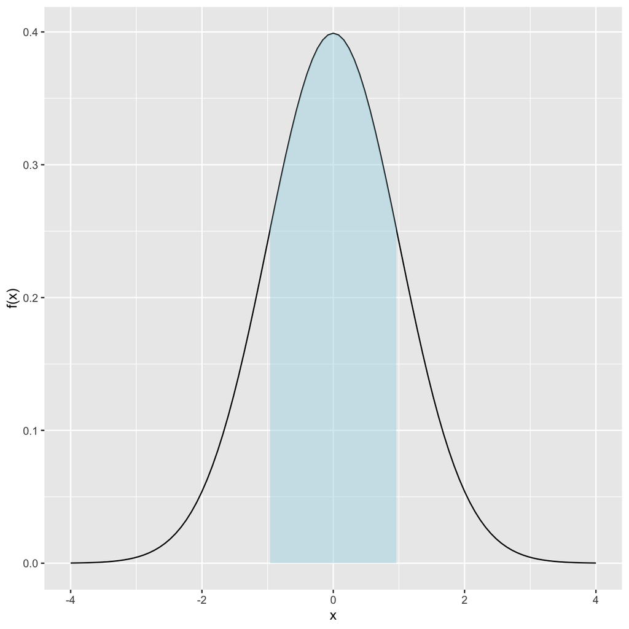

$P( |Z| \leq 1) = 0.68$

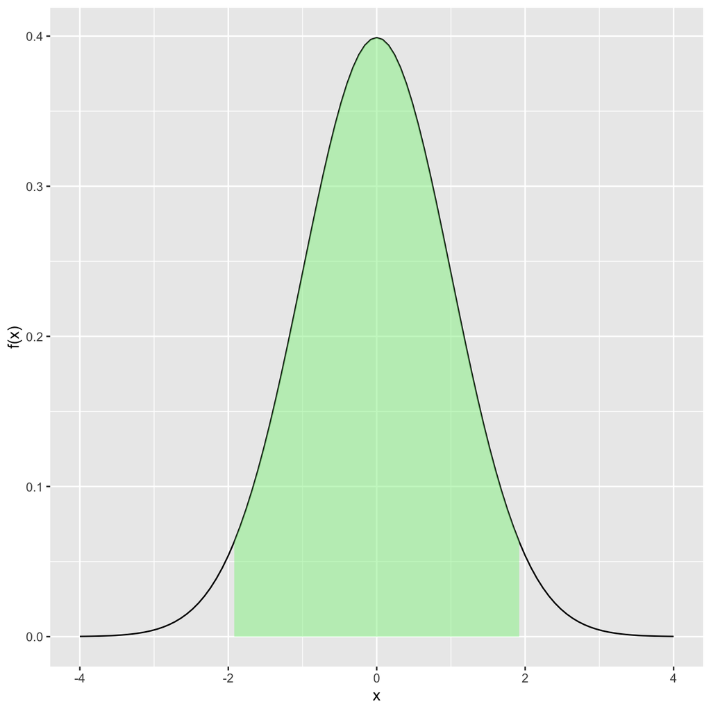

$P( |Z| \leq 2) = 0.95$

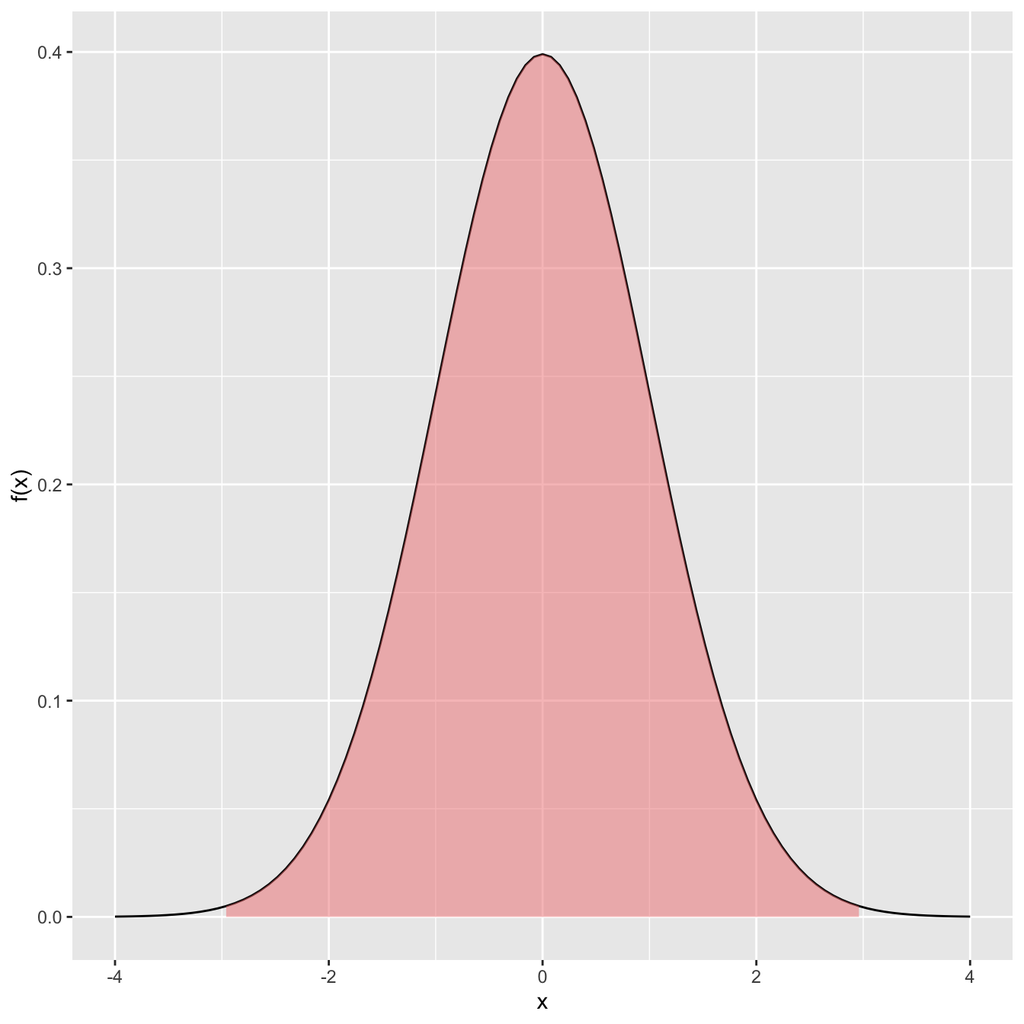

$P( |Z| \leq 3) = 0.997$

## A (potentially) helpful applet

On exams, there will be a link to an applet: [Probability applet](https://people.tamu.edu/~scottcrawford/ftable.html)

Note: This applet is totally optional and unnecessary if you use R

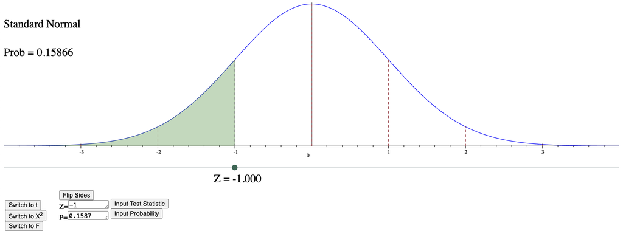

Returning to SAT example:

```r
x       = 600
mu      = 520
sigmaSq = 3600
pnorm(x, mu, sqrt(sigmaSq))
```

```
[1] 0.9087888
```

```r
qnorm(.96, mu, sqrt(sigmaSq))
```

```
[1] 625.0412
```

To use the applet

- Probability: we need the z-score = 1.3333333
- Value: We need to get standardized z-score from applet and then unstandardize to get value.

```r
1.751*sqrt(sigmaSq) + mu
```

```
[1] 625.06
```

(here, 1.751 came from the applet by using the probability .96 from SAT example)

## We’ll be back…

The normal plays a central role in probability and statistics

We will return to it later during sampling distributions…